# Ensemble_Technique_Parkinson_Prediction_Project3

### Ensemble_Technique_Parkinson_Prediction

```python
import numpy as np
import pandas as pd
import seaborn as sns
import matplotlib.pyplot as plt
%matplotlib inline
import sklearn.metrics as metrics
from sklearn.model_selection import cross_val_score
from sklearn.model_selection import KFold
from scipy.stats import zscore
import copy
from sklearn.preprocessing import LabelEncoder
from sklearn.preprocessing import StandardScaler
from sklearn import model_selection
from sklearn.ensemble import GradientBoostingClassifier
from xgboost import XGBClassifier
```

### Load Dataset

Attribute Information:

Matrix column entries (attributes): name - ASCII subject name and recording number MDVP:Fo(Hz) - Average vocal fundamental frequency MDVP:Fhi(Hz) - Maximum vocal fundamental frequency MDVP:Flo(Hz) - Minimum vocal fundamental frequency MDVP:Jitter(%),MDVP:Jitter(Abs),MDVP:RAP,MDVP:PPQ,Jitter:DDP - Several measures of variation in fundamental frequency MDVP:Shimmer,MDVP:Shimmer(dB),Shimmer:APQ3,Shimmer:APQ5,MDVP:APQ,Shimmer:DDA - Several measures of variation in amplitude NHR,HNR - Two measures of ratio of noise to tonal components in the voice status - Health status of the subject (one) - Parkinson's, (zero) - healthy RPDE,D2 - Two nonlinear dynamical complexity measures DFA - Signal fractal scaling exponent spread1,spread2,PPE - Three nonlinear measures of fundamental frequency variation

```python
df_park = pd.read_csv("Data - Parkinsons.txt")
df_park.head()
```

|  | name | MDVP:Fo(Hz) | MDVP:Fhi(Hz) | MDVP:Flo(Hz) | MDVP:Jitter(%) | MDVP:Jitter(Abs) | MDVP:RAP | MDVP:PPQ | Jitter:DDP | MDVP:Shimmer | ... | Shimmer:DDA | NHR | HNR | status | RPDE | DFA | spread1 | spread2 | D2 | PPE |
| --- | --- | --- | --- | --- | --- | --- | --- | --- | --- | --- | --- | --- | --- | --- | --- | --- | --- | --- | --- | --- | --- |
| 0 | phon_R01_S01_1 | 119.992 | 157.302 | 74.997 | 0.00784 | 0.00007 | 0.00370 | 0.00554 | 0.01109 | 0.04374 | ... | 0.06545 | 0.02211 | 21.033 | 1 | 0.414783 | 0.815285 | -4.813031 | 0.266482 | 2.301442 | 0.284654 |
| 1 | phon_R01_S01_2 | 122.400 | 148.650 | 113.819 | 0.00968 | 0.00008 | 0.00465 | 0.00696 | 0.01394 | 0.06134 | ... | 0.09403 | 0.01929 | 19.085 | 1 | 0.458359 | 0.819521 | -4.075192 | 0.335590 | 2.486855 | 0.368674 |
| 2 | phon_R01_S01_3 | 116.682 | 131.111 | 111.555 | 0.01050 | 0.00009 | 0.00544 | 0.00781 | 0.01633 | 0.05233 | ... | 0.08270 | 0.01309 | 20.651 | 1 | 0.429895 | 0.825288 | -4.443179 | 0.311173 | 2.342259 | 0.332634 |
| 3 | phon_R01_S01_4 | 116.676 | 137.871 | 111.366 | 0.00997 | 0.00009 | 0.00502 | 0.00698 | 0.01505 | 0.05492 | ... | 0.08771 | 0.01353 | 20.644 | 1 | 0.434969 | 0.819235 | -4.117501 | 0.334147 | 2.405554 | 0.368975 |
| 4 | phon_R01_S01_5 | 116.014 | 141.781 | 110.655 | 0.01284 | 0.00011 | 0.00655 | 0.00908 | 0.01966 | 0.06425 | ... | 0.10470 | 0.01767 | 19.649 | 1 | 0.417356 | 0.823484 | -3.747787 | 0.234513 | 2.332180 | 0.410335 |

5 rows × 24 columns

### Data Observation

```python
#1. Data Analysis
df_park.shape # It has 195 rows and 24 columns
```

```
(195, 24)
```

```python
df_park.dtypes
```

```
name                 object
MDVP:Fo(Hz)         float64
MDVP:Fhi(Hz)        float64
MDVP:Flo(Hz)        float64
MDVP:Jitter(%)      float64
MDVP:Jitter(Abs)    float64
MDVP:RAP            float64
MDVP:PPQ            float64
Jitter:DDP          float64
MDVP:Shimmer        float64
MDVP:Shimmer(dB)    float64
Shimmer:APQ3        float64
Shimmer:APQ5        float64
MDVP:APQ            float64
Shimmer:DDA         float64
NHR                 float64
HNR                 float64
status                int64
RPDE                float64
DFA                 float64
spread1             float64
spread2             float64
D2                  float64
PPE                 float64
dtype: object
```

Name column is of object type, Rest all has well defined datatype float i.e Frequency can be in decimals. status of the subject (one) - Parkinson's, (zero) - healthy We need one common scaling technique for proper prediction

### Univariate Analysis

```python
df_park.info()
# 22 features float, 1 -  int, 1  -  object
```

```
<class 'pandas.core.frame.DataFrame'>
RangeIndex: 195 entries, 0 to 194
Data columns (total 24 columns):
name                195 non-null object
MDVP:Fo(Hz)         195 non-null float64
MDVP:Fhi(Hz)        195 non-null float64
MDVP:Flo(Hz)        195 non-null float64
MDVP:Jitter(%)      195 non-null float64
MDVP:Jitter(Abs)    195 non-null float64
MDVP:RAP            195 non-null float64
MDVP:PPQ            195 non-null float64
Jitter:DDP          195 non-null float64
MDVP:Shimmer        195 non-null float64
MDVP:Shimmer(dB)    195 non-null float64
Shimmer:APQ3        195 non-null float64
Shimmer:APQ5        195 non-null float64
MDVP:APQ            195 non-null float64
Shimmer:DDA         195 non-null float64
NHR                 195 non-null float64
HNR                 195 non-null float64
status              195 non-null int64
RPDE                195 non-null float64
DFA                 195 non-null float64
spread1             195 non-null float64
spread2             195 non-null float64
D2                  195 non-null float64
PPE                 195 non-null float64
dtypes: float64(22), int64(1), object(1)
memory usage: 36.7+ KB
```

```python
# 5-point summary
df_park.describe().transpose()#summary statistics
```

|  | count | mean | std | min | 25% | 50% | 75% | max |
| --- | --- | --- | --- | --- | --- | --- | --- | --- |
| MDVP:Fo(Hz) | 195.0 | 154.228641 | 41.390065 | 88.333000 | 117.572000 | 148.790000 | 182.769000 | 260.105000 |
| MDVP:Fhi(Hz) | 195.0 | 197.104918 | 91.491548 | 102.145000 | 134.862500 | 175.829000 | 224.205500 | 592.030000 |
| MDVP:Flo(Hz) | 195.0 | 116.324631 | 43.521413 | 65.476000 | 84.291000 | 104.315000 | 140.018500 | 239.170000 |
| MDVP:Jitter(%) | 195.0 | 0.006220 | 0.004848 | 0.001680 | 0.003460 | 0.004940 | 0.007365 | 0.033160 |
| MDVP:Jitter(Abs) | 195.0 | 0.000044 | 0.000035 | 0.000007 | 0.000020 | 0.000030 | 0.000060 | 0.000260 |
| MDVP:RAP | 195.0 | 0.003306 | 0.002968 | 0.000680 | 0.001660 | 0.002500 | 0.003835 | 0.021440 |
| MDVP:PPQ | 195.0 | 0.003446 | 0.002759 | 0.000920 | 0.001860 | 0.002690 | 0.003955 | 0.019580 |
| Jitter:DDP | 195.0 | 0.009920 | 0.008903 | 0.002040 | 0.004985 | 0.007490 | 0.011505 | 0.064330 |
| MDVP:Shimmer | 195.0 | 0.029709 | 0.018857 | 0.009540 | 0.016505 | 0.022970 | 0.037885 | 0.119080 |
| MDVP:Shimmer(dB) | 195.0 | 0.282251 | 0.194877 | 0.085000 | 0.148500 | 0.221000 | 0.350000 | 1.302000 |
| Shimmer:APQ3 | 195.0 | 0.015664 | 0.010153 | 0.004550 | 0.008245 | 0.012790 | 0.020265 | 0.056470 |
| Shimmer:APQ5 | 195.0 | 0.017878 | 0.012024 | 0.005700 | 0.009580 | 0.013470 | 0.022380 | 0.079400 |
| MDVP:APQ | 195.0 | 0.024081 | 0.016947 | 0.007190 | 0.013080 | 0.018260 | 0.029400 | 0.137780 |
| Shimmer:DDA | 195.0 | 0.046993 | 0.030459 | 0.013640 | 0.024735 | 0.038360 | 0.060795 | 0.169420 |
| NHR | 195.0 | 0.024847 | 0.040418 | 0.000650 | 0.005925 | 0.011660 | 0.025640 | 0.314820 |
| HNR | 195.0 | 21.885974 | 4.425764 | 8.441000 | 19.198000 | 22.085000 | 25.075500 | 33.047000 |
| status | 195.0 | 0.753846 | 0.431878 | 0.000000 | 1.000000 | 1.000000 | 1.000000 | 1.000000 |
| RPDE | 195.0 | 0.498536 | 0.103942 | 0.256570 | 0.421306 | 0.495954 | 0.587562 | 0.685151 |
| DFA | 195.0 | 0.718099 | 0.055336 | 0.574282 | 0.674758 | 0.722254 | 0.761881 | 0.825288 |
| spread1 | 195.0 | -5.684397 | 1.090208 | -7.964984 | -6.450096 | -5.720868 | -5.046192 | -2.434031 |
| spread2 | 195.0 | 0.226510 | 0.083406 | 0.006274 | 0.174351 | 0.218885 | 0.279234 | 0.450493 |
| D2 | 195.0 | 2.381826 | 0.382799 | 1.423287 | 2.099125 | 2.361532 | 2.636456 | 3.671155 |
| PPE | 195.0 | 0.206552 | 0.090119 | 0.044539 | 0.137451 | 0.194052 | 0.252980 | 0.527367 |

### MDVP:Fo(Hz) and MDVP:Flo(Hz) has deviation closer to 50%

### Here 50% quantile also known as median, we use median because the median cannot be affected by outliers. Where mean is easily affected by outliers.

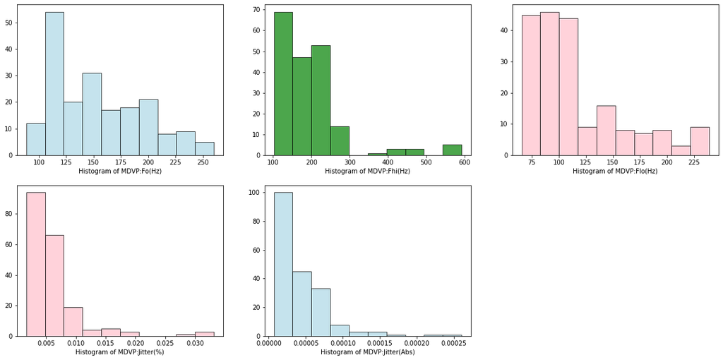

```python
#Distribution of MDVP:Fo(Hz),MDVP:Fhi(Hz),MDVP:Flo(Hz),MDVP:Jitter(%),MDVP:Jitter(Abs)
#Data Visualisation

plt.figure(figsize= (20,15))
plt.subplot(3,3,1)
plt.hist(df_park["MDVP:Fo(Hz)"].dropna(), color='lightblue', edgecolor = 'black', alpha = 0.7)
plt.xlabel('Histogram of MDVP:Fo(Hz)')

plt.subplot(3,3,2)
plt.hist(df_park["MDVP:Fhi(Hz)"].dropna(), color='green', edgecolor = 'black', alpha = 0.7)
plt.xlabel('Histogram of MDVP:Fhi(Hz)')

plt.subplot(3,3,3)
plt.hist(df_park["MDVP:Flo(Hz)"], color='pink', edgecolor = 'black', alpha = 0.7)
plt.xlabel('Histogram of MDVP:Flo(Hz)')

plt.subplot(3,3,4)
plt.hist(df_park["MDVP:Jitter(%)"], color='pink', edgecolor = 'black', alpha = 0.7)
plt.xlabel('Histogram of MDVP:Jitter(%)')

plt.subplot(3,3,5)
plt.hist(df_park["MDVP:Jitter(Abs)"].dropna(), color='lightblue', edgecolor = 'black', alpha = 0.7)
plt.xlabel('Histogram of MDVP:Jitter(Abs)')
```

### Rest all are right skewed

## Target column Distribution

```python
# 1. Using Value count
df_park['status'].value_counts(normalize= True)
```

```
1    0.753846
0    0.246154
Name: status, dtype: float64
```

```python
df_park.groupby("status").agg({'status': 'count'})
```

| status | status |
| --- | --- |
| 0 | 48 |
| 1 | 147 |

#### It has class imbalance True - 75 %, False - 25 %

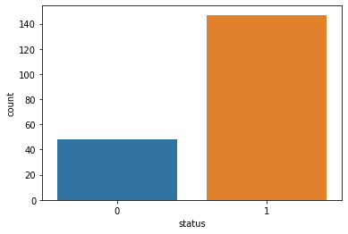

```python
sns.countplot(df_park['status'])
```

## Bivariate and MultiVariate analysis with correlation

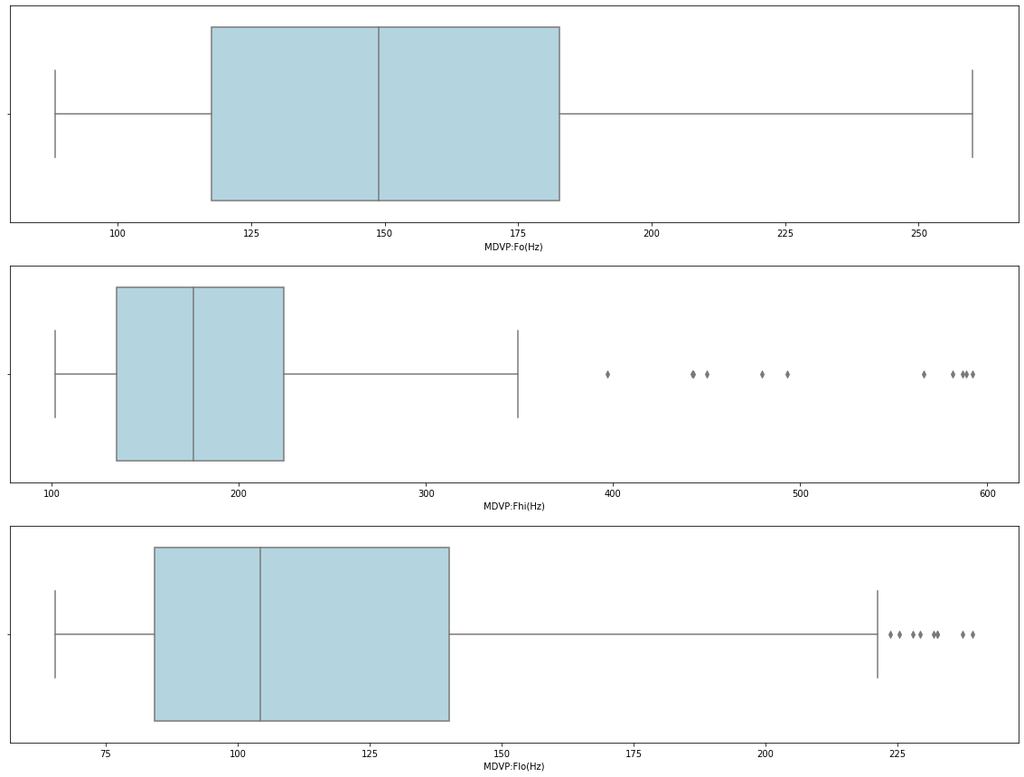

```python
#2.Checking the presence of outliers in ‘bmi’, ‘age’ and ‘charges columns
#Checking for the outliers
plt.figure(figsize= (20,15))
plt.subplot(3,1,1)
sns.boxplot(x= df_park["MDVP:Fo(Hz)"], color='lightblue')

plt.subplot(3,1,2)
sns.boxplot(x= df_park["MDVP:Fhi(Hz)"], color='lightblue')

plt.subplot(3,1,3)
sns.boxplot(x= df_park["MDVP:Flo(Hz)"], color='lightblue')
```

### MDVP:Fhi(Hz) and MDVP:Flo(Hz) has outliers where as MDVP:Fo(Hz) is evenly distributed.

[figure not shown]

```python
## Boxplot between two
sns.boxplot(x = "PPE",y="MDVP:Flo(Hz)", hue="status", data=df_park)
#Observation
#Not very clear from this but high Flo and less PPE has less chance of parkinson
#have the same income distribution regardless of the education level.
```

```python
# Correlation
df_park.corr()
```

|  | MDVP:Fo(Hz) | MDVP:Fhi(Hz) | MDVP:Flo(Hz) | MDVP:Jitter(%) | MDVP:Jitter(Abs) | MDVP:RAP | MDVP:PPQ | Jitter:DDP | MDVP:Shimmer | MDVP:Shimmer(dB) | ... | Shimmer:DDA | NHR | HNR | status | RPDE | DFA | spread1 | spread2 | D2 | PPE |
| --- | --- | --- | --- | --- | --- | --- | --- | --- | --- | --- | --- | --- | --- | --- | --- | --- | --- | --- | --- | --- | --- |
| MDVP:Fo(Hz) | 1.000000 | 0.400985 | 0.596546 | -0.118003 | -0.382027 | -0.076194 | -0.112165 | -0.076213 | -0.098374 | -0.073742 | ... | -0.094732 | -0.021981 | 0.059144 | -0.383535 | -0.383894 | -0.446013 | -0.413738 | -0.249450 | 0.177980 | -0.372356 |
| MDVP:Fhi(Hz) | 0.400985 | 1.000000 | 0.084951 | 0.102086 | -0.029198 | 0.097177 | 0.091126 | 0.097150 | 0.002281 | 0.043465 | ... | -0.003733 | 0.163766 | -0.024893 | -0.166136 | -0.112404 | -0.343097 | -0.076658 | -0.002954 | 0.176323 | -0.069543 |
| MDVP:Flo(Hz) | 0.596546 | 0.084951 | 1.000000 | -0.139919 | -0.277815 | -0.100519 | -0.095828 | -0.100488 | -0.144543 | -0.119089 | ... | -0.150737 | -0.108670 | 0.210851 | -0.380200 | -0.400143 | -0.050406 | -0.394857 | -0.243829 | -0.100629 | -0.340071 |
| MDVP:Jitter(%) | -0.118003 | 0.102086 | -0.139919 | 1.000000 | 0.935714 | 0.990276 | 0.974256 | 0.990276 | 0.769063 | 0.804289 | ... | 0.746635 | 0.906959 | -0.728165 | 0.278220 | 0.360673 | 0.098572 | 0.693577 | 0.385123 | 0.433434 | 0.721543 |
| MDVP:Jitter(Abs) | -0.382027 | -0.029198 | -0.277815 | 0.935714 | 1.000000 | 0.922911 | 0.897778 | 0.922913 | 0.703322 | 0.716601 | ... | 0.697170 | 0.834972 | -0.656810 | 0.338653 | 0.441839 | 0.175036 | 0.735779 | 0.388543 | 0.310694 | 0.748162 |
| MDVP:RAP | -0.076194 | 0.097177 | -0.100519 | 0.990276 | 0.922911 | 1.000000 | 0.957317 | 1.000000 | 0.759581 | 0.790652 | ... | 0.744919 | 0.919521 | -0.721543 | 0.266668 | 0.342140 | 0.064083 | 0.648328 | 0.324407 | 0.426605 | 0.670999 |
| MDVP:PPQ | -0.112165 | 0.091126 | -0.095828 | 0.974256 | 0.897778 | 0.957317 | 1.000000 | 0.957319 | 0.797826 | 0.839239 | ... | 0.763592 | 0.844604 | -0.731510 | 0.288698 | 0.333274 | 0.196301 | 0.716489 | 0.407605 | 0.412524 | 0.769647 |
| Jitter:DDP | -0.076213 | 0.097150 | -0.100488 | 0.990276 | 0.922913 | 1.000000 | 0.957319 | 1.000000 | 0.759555 | 0.790621 | ... | 0.744901 | 0.919548 | -0.721494 | 0.266646 | 0.342079 | 0.064026 | 0.648328 | 0.324377 | 0.426556 | 0.671005 |
| MDVP:Shimmer | -0.098374 | 0.002281 | -0.144543 | 0.769063 | 0.703322 | 0.759581 | 0.797826 | 0.759555 | 1.000000 | 0.987258 | ... | 0.987626 | 0.722194 | -0.835271 | 0.367430 | 0.447424 | 0.159954 | 0.654734 | 0.452025 | 0.507088 | 0.693771 |
| MDVP:Shimmer(dB) | -0.073742 | 0.043465 | -0.119089 | 0.804289 | 0.716601 | 0.790652 | 0.839239 | 0.790621 | 0.987258 | 1.000000 | ... | 0.963202 | 0.744477 | -0.827805 | 0.350697 | 0.410684 | 0.165157 | 0.652547 | 0.454314 | 0.512233 | 0.695058 |
| Shimmer:APQ3 | -0.094717 | -0.003743 | -0.150747 | 0.746625 | 0.697153 | 0.744912 | 0.763580 | 0.744894 | 0.987625 | 0.963198 | ... | 1.000000 | 0.716207 | -0.827123 | 0.347617 | 0.435242 | 0.151124 | 0.610967 | 0.402243 | 0.467265 | 0.645377 |
| Shimmer:APQ5 | -0.070682 | -0.009997 | -0.101095 | 0.725561 | 0.648961 | 0.709927 | 0.786780 | 0.709907 | 0.982835 | 0.973751 | ... | 0.960072 | 0.658080 | -0.813753 | 0.351148 | 0.399903 | 0.213873 | 0.646809 | 0.457195 | 0.502174 | 0.702456 |
| MDVP:APQ | -0.077774 | 0.004937 | -0.107293 | 0.758255 | 0.648793 | 0.737455 | 0.804139 | 0.737439 | 0.950083 | 0.960977 | ... | 0.896647 | 0.694019 | -0.800407 | 0.364316 | 0.451379 | 0.157276 | 0.673158 | 0.502188 | 0.536869 | 0.721694 |
| Shimmer:DDA | -0.094732 | -0.003733 | -0.150737 | 0.746635 | 0.697170 | 0.744919 | 0.763592 | 0.744901 | 0.987626 | 0.963202 | ... | 1.000000 | 0.716215 | -0.827130 | 0.347608 | 0.435237 | 0.151132 | 0.610971 | 0.402223 | 0.467261 | 0.645389 |
| NHR | -0.021981 | 0.163766 | -0.108670 | 0.906959 | 0.834972 | 0.919521 | 0.844604 | 0.919548 | 0.722194 | 0.744477 | ... | 0.716215 | 1.000000 | -0.714072 | 0.189429 | 0.370890 | -0.131882 | 0.540865 | 0.318099 | 0.470949 | 0.552591 |
| HNR | 0.059144 | -0.024893 | 0.210851 | -0.728165 | -0.656810 | -0.721543 | -0.731510 | -0.721494 | -0.835271 | -0.827805 | ... | -0.827130 | -0.714072 | 1.000000 | -0.361515 | -0.598736 | -0.008665 | -0.673210 | -0.431564 | -0.601401 | -0.692876 |
| status | -0.383535 | -0.166136 | -0.380200 | 0.278220 | 0.338653 | 0.266668 | 0.288698 | 0.266646 | 0.367430 | 0.350697 | ... | 0.347608 | 0.189429 | -0.361515 | 1.000000 | 0.308567 | 0.231739 | 0.564838 | 0.454842 | 0.340232 | 0.531039 |
| RPDE | -0.383894 | -0.112404 | -0.400143 | 0.360673 | 0.441839 | 0.342140 | 0.333274 | 0.342079 | 0.447424 | 0.410684 | ... | 0.435237 | 0.370890 | -0.598736 | 0.308567 | 1.000000 | -0.110950 | 0.591117 | 0.479905 | 0.236931 | 0.545886 |
| DFA | -0.446013 | -0.343097 | -0.050406 | 0.098572 | 0.175036 | 0.064083 | 0.196301 | 0.064026 | 0.159954 | 0.165157 | ... | 0.151132 | -0.131882 | -0.008665 | 0.231739 | -0.110950 | 1.000000 | 0.195668 | 0.166548 | -0.165381 | 0.270445 |
| spread1 | -0.413738 | -0.076658 | -0.394857 | 0.693577 | 0.735779 | 0.648328 | 0.716489 | 0.648328 | 0.654734 | 0.652547 | ... | 0.610971 | 0.540865 | -0.673210 | 0.564838 | 0.591117 | 0.195668 | 1.000000 | 0.652358 | 0.495123 | 0.962435 |
| spread2 | -0.249450 | -0.002954 | -0.243829 | 0.385123 | 0.388543 | 0.324407 | 0.407605 | 0.324377 | 0.452025 | 0.454314 | ... | 0.402223 | 0.318099 | -0.431564 | 0.454842 | 0.479905 | 0.166548 | 0.652358 | 1.000000 | 0.523532 | 0.644711 |
| D2 | 0.177980 | 0.176323 | -0.100629 | 0.433434 | 0.310694 | 0.426605 | 0.412524 | 0.426556 | 0.507088 | 0.512233 | ... | 0.467261 | 0.470949 | -0.601401 | 0.340232 | 0.236931 | -0.165381 | 0.495123 | 0.523532 | 1.000000 | 0.480585 |
| PPE | -0.372356 | -0.069543 | -0.340071 | 0.721543 | 0.748162 | 0.670999 | 0.769647 | 0.671005 | 0.693771 | 0.695058 | ... | 0.645389 | 0.552591 | -0.692876 | 0.531039 | 0.545886 | 0.270445 | 0.962435 | 0.644711 | 0.480585 | 1.000000 |

23 rows × 23 columns

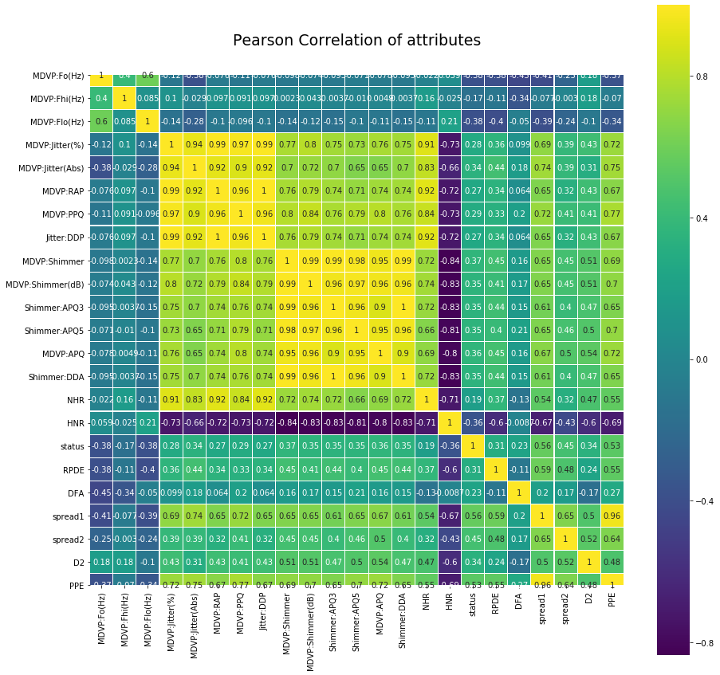

```python
#1. Correlation Analysis and Bivariate Classification
colormap = plt.cm.viridis # Color range to be used in heatmap
plt.figure(figsize=(15,15))
plt.title('Pearson Correlation of attributes', y=1.05, size=19)
sns.heatmap(df_park.corr(),linewidths=0.1,vmax=1.0,
            square=True, cmap=colormap, linecolor='white', annot=True)
#There are strong correlation between many two variables like PPE and MDVP
#MDVP frequency are highly correlated with 3 of each other
```

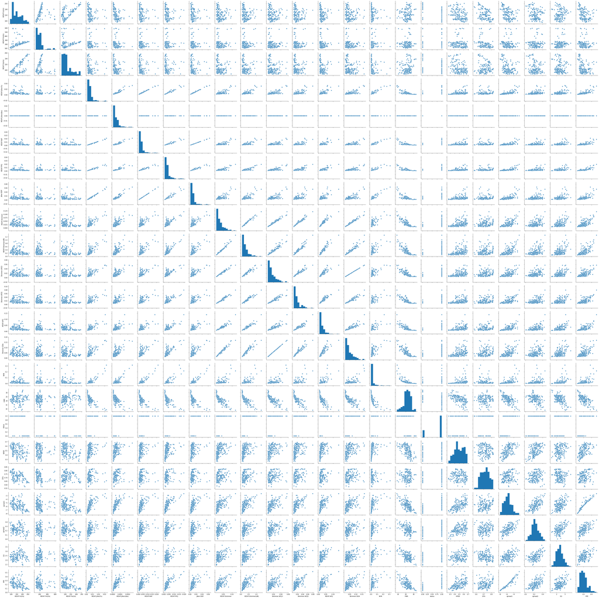

```python
## multivariate analysis
sns.pairplot(data = df_park)
```

## Data Cleaning and getting rid of missing values

```python
#Reading Data
# Making a list of missing value types
missing_values = ["n/a", "na", "--", "?"]
df_park_missing = pd.read_csv("Data - Parkinsons.txt", na_values = missing_values) #df => dataframe
type(df_park_missing) #pandas.core.frame.DataFrame
print(df_park_missing.shape) # shape=> rows,columns
df_park_missing.head() #inspecting first 5 rows
```

```
(195, 24)
```

|  | name | MDVP:Fo(Hz) | MDVP:Fhi(Hz) | MDVP:Flo(Hz) | MDVP:Jitter(%) | MDVP:Jitter(Abs) | MDVP:RAP | MDVP:PPQ | Jitter:DDP | MDVP:Shimmer | ... | Shimmer:DDA | NHR | HNR | status | RPDE | DFA | spread1 | spread2 | D2 | PPE |
| --- | --- | --- | --- | --- | --- | --- | --- | --- | --- | --- | --- | --- | --- | --- | --- | --- | --- | --- | --- | --- | --- |
| 0 | phon_R01_S01_1 | 119.992 | 157.302 | 74.997 | 0.00784 | 0.00007 | 0.00370 | 0.00554 | 0.01109 | 0.04374 | ... | 0.06545 | 0.02211 | 21.033 | 1 | 0.414783 | 0.815285 | -4.813031 | 0.266482 | 2.301442 | 0.284654 |
| 1 | phon_R01_S01_2 | 122.400 | 148.650 | 113.819 | 0.00968 | 0.00008 | 0.00465 | 0.00696 | 0.01394 | 0.06134 | ... | 0.09403 | 0.01929 | 19.085 | 1 | 0.458359 | 0.819521 | -4.075192 | 0.335590 | 2.486855 | 0.368674 |
| 2 | phon_R01_S01_3 | 116.682 | 131.111 | 111.555 | 0.01050 | 0.00009 | 0.00544 | 0.00781 | 0.01633 | 0.05233 | ... | 0.08270 | 0.01309 | 20.651 | 1 | 0.429895 | 0.825288 | -4.443179 | 0.311173 | 2.342259 | 0.332634 |
| 3 | phon_R01_S01_4 | 116.676 | 137.871 | 111.366 | 0.00997 | 0.00009 | 0.00502 | 0.00698 | 0.01505 | 0.05492 | ... | 0.08771 | 0.01353 | 20.644 | 1 | 0.434969 | 0.819235 | -4.117501 | 0.334147 | 2.405554 | 0.368975 |
| 4 | phon_R01_S01_5 | 116.014 | 141.781 | 110.655 | 0.01284 | 0.00011 | 0.00655 | 0.00908 | 0.01966 | 0.06425 | ... | 0.10470 | 0.01767 | 19.649 | 1 | 0.417356 | 0.823484 | -3.747787 | 0.234513 | 2.332180 | 0.410335 |

5 rows × 24 columns

```python
#Data cleaning
df_park.isna().sum() #no null or N/A values as isnull is 0
```

```
name                0
MDVP:Fo(Hz)         0
MDVP:Fhi(Hz)        0
MDVP:Flo(Hz)        0
MDVP:Jitter(%)      0
MDVP:Jitter(Abs)    0
MDVP:RAP            0
MDVP:PPQ            0
Jitter:DDP          0
MDVP:Shimmer        0
MDVP:Shimmer(dB)    0
Shimmer:APQ3        0
Shimmer:APQ5        0
MDVP:APQ            0
Shimmer:DDA         0
NHR                 0
HNR                 0
status              0
RPDE                0
DFA                 0
spread1             0
spread2             0
D2                  0
PPE                 0
dtype: int64
```

```python
#Check for the null values
df_park.isnull().apply(pd.value_counts)
```

|  | name | MDVP:Fo(Hz) | MDVP:Fhi(Hz) | MDVP:Flo(Hz) | MDVP:Jitter(%) | MDVP:Jitter(Abs) | MDVP:RAP | MDVP:PPQ | Jitter:DDP | MDVP:Shimmer | ... | Shimmer:DDA | NHR | HNR | status | RPDE | DFA | spread1 | spread2 | D2 | PPE |
| --- | --- | --- | --- | --- | --- | --- | --- | --- | --- | --- | --- | --- | --- | --- | --- | --- | --- | --- | --- | --- | --- |
| False | 195 | 195 | 195 | 195 | 195 | 195 | 195 | 195 | 195 | 195 | ... | 195 | 195 | 195 | 195 | 195 | 195 | 195 | 195 | 195 | 195 |

1 rows × 24 columns

```python
## dropping Name feature as it is not needed
df_park = df_park.drop(["name"],axis = 1)
```

### Feature scaling

#### The idea behind Standard Scaler is that it will transform your data, such that the distribution will have a mean value of 0 and a standard deviation of 1.

```python
## Using standardscaler
#x_scaled = (x — u) / s
from sklearn.preprocessing import StandardScaler
X = df_park.drop(['status'],axis=1)
scaler = StandardScaler()
scaler.fit_transform(X)
```

```
array([[-0.82929965, -0.43616456, -0.95203729, ...,  0.48047686,
        -0.21053082,  0.86888575],
       [-0.77097169, -0.53097409, -0.05772056, ...,  1.31118546,
         0.27507712,  1.80360503],
       [-0.90947638, -0.7231683 , -0.10987483, ...,  1.01768236,
        -0.10362861,  1.40266141],
       ...,
       [ 0.49557839,  0.47010361, -0.96839309, ..., -0.81807931,
         0.78033848, -0.83241014],
       [ 1.07876114,  2.19004398, -0.95417967, ..., -0.22906571,
        -0.63700298, -0.92610456],
       [ 1.45481664,  0.69224632, -0.88348115, ..., -0.43085284,
         0.45480231, -0.64505466]])
```

### Split the dataset into training and test set in the ratio of 70:30

```python
from sklearn.model_selection import train_test_split
X   # Predictor feature columns (22 X m)
Y = df_park['status']   # Predicted class (1=True, 0=False) (1 X m)

x_train, x_test, y_train, y_test = train_test_split(X, Y, test_size=0.3, random_state=1)
# 1 is just any random seed number

x_train.head()
```

|  | MDVP:Fo(Hz) | MDVP:Fhi(Hz) | MDVP:Flo(Hz) | MDVP:Jitter(%) | MDVP:Jitter(Abs) | MDVP:RAP | MDVP:PPQ | Jitter:DDP | MDVP:Shimmer | MDVP:Shimmer(dB) | ... | MDVP:APQ | Shimmer:DDA | NHR | HNR | RPDE | DFA | spread1 | spread2 | D2 | PPE |
| --- | --- | --- | --- | --- | --- | --- | --- | --- | --- | --- | --- | --- | --- | --- | --- | --- | --- | --- | --- | --- | --- |
| 42 | 237.226 | 247.326 | 225.227 | 0.00298 | 0.00001 | 0.00169 | 0.00182 | 0.00507 | 0.01752 | 0.164 | ... | 0.01133 | 0.03104 | 0.00740 | 22.736 | 0.305062 | 0.654172 | -7.310550 | 0.098648 | 2.416838 | 0.095032 |
| 17 | 168.778 | 232.181 | 75.603 | 0.00718 | 0.00004 | 0.00284 | 0.00387 | 0.00853 | 0.03327 | 0.348 | ... | 0.03430 | 0.04322 | 0.02919 | 20.376 | 0.631099 | 0.605417 | -2.931070 | 0.434326 | 3.007463 | 0.430788 |
| 5 | 120.552 | 131.162 | 113.787 | 0.00968 | 0.00008 | 0.00463 | 0.00750 | 0.01388 | 0.04701 | 0.456 | ... | 0.03243 | 0.06985 | 0.01222 | 21.378 | 0.415564 | 0.825069 | -4.242867 | 0.299111 | 2.187560 | 0.357775 |
| 120 | 128.940 | 479.697 | 88.251 | 0.00581 | 0.00005 | 0.00241 | 0.00314 | 0.00723 | 0.02008 | 0.221 | ... | 0.01734 | 0.02548 | 0.02350 | 24.743 | 0.487756 | 0.684130 | -6.186128 | 0.279933 | 2.686240 | 0.152428 |
| 98 | 125.791 | 140.557 | 96.206 | 0.01378 | 0.00011 | 0.00826 | 0.00655 | 0.02478 | 0.04689 | 0.422 | ... | 0.03908 | 0.07625 | 0.10323 | 15.433 | 0.571010 | 0.690892 | -5.159169 | 0.202146 | 2.441612 | 0.260375 |

5 rows × 22 columns

```python
# check split of data
print("{0:0.2f}% data is in training set".format((len(x_train)/len(df_park.index)) * 100))
print("{0:0.2f}% data is in test set".format((len(x_test)/len(df_park.index)) * 100))
```

```
69.74% data is in training set
30.26% data is in test set
```

### Train with 3 classification algorithm

### Accuracy = TP+TN/TP+FP+FN+TN

TP = True positives TN = True negatives FN = False negatives TN = True negatives

### Logistic Regression

```python
# Logistic Regression
from sklearn.linear_model import LogisticRegression

# Fit the model on train
model = LogisticRegression(solver="liblinear")
model.fit(x_train, y_train)
#predict on test
y_predict = model.predict(x_test)


coef_df = pd.DataFrame(model.coef_)
coef_df['intercept'] = model.intercept_
print(coef_df)
```

```
         0         1         2         3         4        5         6  \
0 -0.00854 -0.004358 -0.002338  0.008541  0.000071  0.00795  0.007116

          7         8         9  ...        13        14        15        16  \
0  0.023852  0.105716  1.021564  ...  0.168584  0.033325  0.070441  0.529799

         17        18        19        20        21  intercept
0  0.737274  0.960551  0.419711  2.621596  0.530123   0.722592

[1 rows x 23 columns]
```

```python
model_score = model.score(x_test, y_test)
print(model_score)

## Model score = 81.35 %

accuracy_score = metrics.accuracy_score(y_test,y_predict)
print (accuracy_score)
## Accuracy score = 81.355 %
```

```
0.8135593220338984
0.8135593220338984
```

### Naive Bayes'

```python
from sklearn.naive_bayes import GaussianNB # using Gaussian algorithm from Naive Bayes

# creatw the model
NN_model = GaussianNB()

NN_model.fit(x_train, y_train.ravel())
```

```
GaussianNB(priors=None, var_smoothing=1e-09)
```

```python
model_score = NN_model.score(x_test,y_test)
print(model_score)
## Model score = 71.18 %

y_predict = NN_model.predict(x_test)
accuracy_score = metrics.accuracy_score(y_test,y_predict)
print (accuracy_score)
## Accuracy score = 71.18 %
```

```
0.711864406779661
0.711864406779661
```

### KNN

```python
from sklearn.neighbors import KNeighborsClassifier
# It is always adviced to scale numeric attributes in models that calculate distances.
# Build KNN Model
NNH = KNeighborsClassifier(n_neighbors= 5 , weights = 'distance' )
NNH.fit(x_train,y_train)
model_score = NNH.score(x_test, y_test)

print(model_score)
## Model score = 81.35 %

y_predict = NNH.predict(x_test)
accuracy_score = metrics.accuracy_score(y_test,y_predict)
print (accuracy_score)
## Accuracy score = 81.35 %
```

```
0.8135593220338984
0.8135593220338984
```

### Train a meta-classifier and note accuracy

Stacking Stacking is an ensemble learning technique that combines multiple classification or regression models via a meta-classifier or a meta-regressor. The base level models are trained based on complete training set then the meta-model is trained on the outputs of base level model as features. The base level often consists of different learning algorithms and therefore stacking ensembles are often heterogeneous.

```python
## Based on above algorithm, we will combine those and train meta classifier for better accuracy
from sklearn.ensemble import RandomForestClassifier
from sklearn.ensemble import StackingClassifier

models = []
models.append(('KNN', KNeighborsClassifier()))
models.append(('RF', RandomForestClassifier(random_state=1)))
models.append(('NB', GaussianNB()))
lr = LogisticRegression()
sclf = StackingClassifier(estimators= models,
                          final_estimator=lr)
```

```python
sclf.fit(x_train, y_train).score(x_test, y_test)
## score =  81.35 %
```

```
0.8135593220338984
```

### Train at least one standard Ensemble model - Random forest, Bagging, Boosting etc, and note the accuracy

### Random Forest

```python
from sklearn.ensemble import RandomForestClassifier
rfcl = RandomForestClassifier(criterion = 'entropy', class_weight={0:.5,1:.5}, max_depth = 5, min_samples_leaf=5)
rfcl = rfcl.fit(x_train, y_train)
y_predict = rfcl.predict(x_test)
rfcl.score(x_test , y_test)

accuracy_score = metrics.accuracy_score(y_test,y_predict)
print (accuracy_score)
## Accuracy score = 83.05 %
```

```
0.8305084745762712
```

### Bagging Classifier

```python
from sklearn.ensemble import BaggingClassifier

bgcl = BaggingClassifier(n_estimators=10, max_samples= .7, bootstrap=True)
bgcl = bgcl.fit(x_train, y_train)

y_predict = bgcl.predict(x_test)
bgcl.score(x_test , y_test)

accuracy_score = metrics.accuracy_score(y_test,y_predict)
print (accuracy_score)
## Accuracy score = 81.35 %
```

```
0.8305084745762712
```

### AdaBoostClassifier

```python
from sklearn.ensemble import AdaBoostClassifier
#abcl = AdaBoostClassifier(base_estimator=dt_model, n_estimators=50)
abcl = AdaBoostClassifier( n_estimators= 20)
abcl = abcl.fit(x_train, y_train)

y_predict = abcl.predict(x_test)
abcl.score(x_test , y_test)

accuracy_score = metrics.accuracy_score(y_test,y_predict)
print (accuracy_score)
## Accuracy score = 88.135 %
```

```
0.8813559322033898
```

### Compare all the models (minimum 5) and pick the best one among them

We will do Cross validation with score, Mean and standard deviation using KFold

```
KNN: 0.721053 (0.176280)
Logistic: 0.807895 (0.187921)
NB: 0.674737 (0.239734)
```

```
GB: 0.809737 (0.193699)
```

```
AB: 0.772368 (0.200042)
```

```
XGB: 0.809737 (0.180070)
```

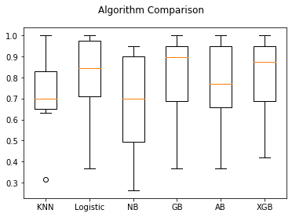

```python
## Model Comparison
models = []
models.append(('KNN', KNeighborsClassifier()))
models.append(('Logistic', LogisticRegression(solver="liblinear")))
models.append(('NB', GaussianNB()))
models.append(('GB',GradientBoostingClassifier(n_estimators = 50, learning_rate = 0.05)))
models.append(('AB',AdaBoostClassifier( n_estimators= 20)))
models.append(('XGB',XGBClassifier()))

# evaluate each model in turn
results = []
names = []
scoring = 'accuracy'
for name, model in models:
	kfold = model_selection.KFold(n_splits=10, random_state=12345)
	cv_results = model_selection.cross_val_score(model, X, Y, cv=kfold, scoring=scoring)
	results.append(cv_results)
	names.append(name)
	msg = "%s: %f (%f)" % (name, cv_results.mean(), cv_results.std())
	print(msg)
# boxplot algorithm comparison
fig = plt.figure()
fig.suptitle('Algorithm Comparison')
ax = fig.add_subplot(111)
plt.boxplot(results)
ax.set_xticklabels(names)
plt.show()
```

### From above score and SD and grapgh(boxplot) - Xtreme Gradient Boost performs better i.e 80.97% ,SD -0.18 .